# COVID-19 Global Case Analysis

Bilal

2025-07-12

## Introduction

The COVID-19 pandemic has affected nearly every country worldwide. This report analyzes the global trends of confirmed cases using time series data provided by the Johns Hopkins University Center for Systems Science and Engineering (JHU CSSE).

Question of Interest: How have COVID-19 confirmed case counts evolved globally and regionally, and can we model short-term growth trends for selected countries?

## Data Source

Source: [JHU CSSE COVID-19 GitHub Repository](https://github.com/CSSEGISandData/COVID-19/tree/master/csse_covid_19_data/csse_covid_19_time_series)

Dataset Description: Time series data on confirmed COVID-19 cases reported by country/region.

## Data Wrangling

```r
confirmed_long <- confirmed_raw %>%
  pivot_longer(cols = starts_with("x"),
               names_to = "date",
               values_to = "cases") %>%
  mutate(date = mdy(str_remove(date, "x")))

# Summarize global totals
global_confirmed <- confirmed_long %>%
  group_by(date) %>%
  summarise(total_cases = sum(cases, na.rm = TRUE))

glimpse(global_confirmed)
```

```
## Rows: 1,143
## Columns: 2
## $ date        <date> 2020-01-22, 2020-01-23, 2020-01-24, 2020-01-25, 2020-01-2…
## $ total_cases <dbl> 557, 657, 944, 1437, 2120, 2929, 5580, 6169, 8237, 9927, 1…
```

## Exploratory Data Analysis

### Global Growth Trend

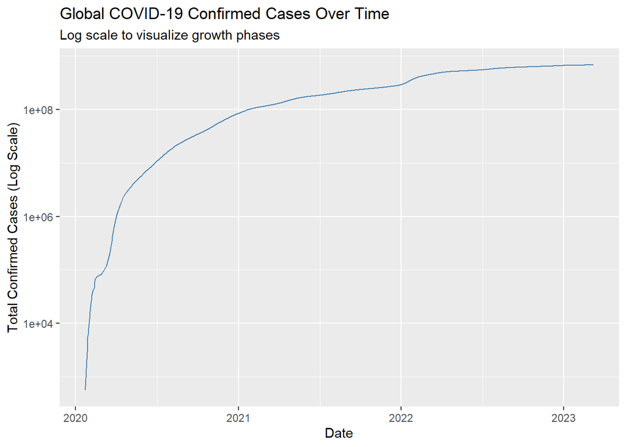

```r
ggplot(global_confirmed, aes(x = date, y = total_cases)) +
  geom_line(color = "steelblue") +
  scale_y_log10() +
  labs(title = "Global COVID-19 Confirmed Cases Over Time",
       subtitle = "Log scale to visualize growth phases",
       x = "Date", y = "Total Confirmed Cases (Log Scale)")
```

### Regional Comparison

[figure not shown]

```r
top_countries <- confirmed_long %>%
  filter(date == max(date)) %>%
  group_by(country_region) %>%
  summarise(total_cases = sum(cases, na.rm = TRUE)) %>%
  arrange(desc(total_cases)) %>%
  slice(1:6) %>%
  pull(country_region)

regional_trends <- confirmed_long %>%
  filter(country_region %in% top_countries) %>%
  group_by(country_region, date) %>%
  summarise(cases = sum(cases, na.rm = TRUE), .groups = "drop")

#regional_trends <- regional_trends[regional_trends$country_region != 'France',]

ggplot(regional_trends, aes(x = date, y = cases, color = country_region)) +
  geom_line() +
  labs(title = "COVID-19 Confirmed Cases in Top 5 Countries",
       x = "Date", y = "Confirmed Cases") + theme_minimal()
```

## Statistical Modeling

We model the global case growth using a simple log-linear model:

```r
global_confirmed <- global_confirmed %>%
  filter(total_cases > 0)

global_confirmed <- global_confirmed %>%
  mutate(log_cases = log(total_cases),
         days_since_start = as.numeric(date - min(date)))

model <- lm(log_cases ~ days_since_start, data = global_confirmed)
summary(model)
```

```
##
## Call:
## lm(formula = log_cases ~ days_since_start, data = global_confirmed)
##
## Residuals:
##     Min      1Q  Median      3Q     Max
## -8.5676 -0.4864  0.3276  0.9086  1.2892
##
## Coefficients:
##                   Estimate Std. Error t value Pr(>|t|)
## (Intercept)      1.489e+01  7.901e-02  188.46   <2e-16 ***
## days_since_start 6.083e-03  1.198e-04   50.78   <2e-16 ***
## ---
## Signif. codes:  0 '***' 0.001 '**' 0.01 '*' 0.05 '.' 0.1 ' ' 1
##
## Residual standard error: 1.336 on 1141 degrees of freedom
## Multiple R-squared:  0.6932, Adjusted R-squared:  0.6929
## F-statistic:  2578 on 1 and 1141 DF,  p-value: < 2.2e-16
```

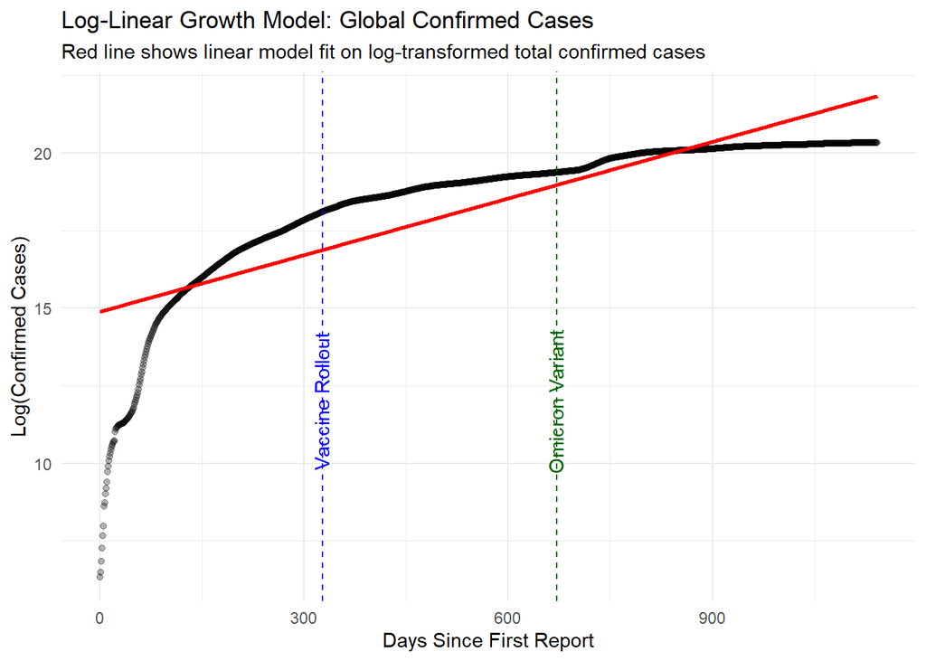

```r
model_augmented <- augment(model, global_confirmed)

# Define key events
vaccine_date <- as.numeric(ymd("2020-12-14") - min(global_confirmed$date))  # Pfizer vaccine
omicron_date <- as.numeric(ymd("2021-11-24") - min(global_confirmed$date))  # Omicron identified

ggplot(model_augmented, aes(x = days_since_start, y = log_cases)) +
  geom_point(alpha = 0.3, color = "black") +
  geom_line(aes(y = .fitted), color = "red", linewidth = 1) +
  geom_vline(xintercept = vaccine_date, linetype = "dashed", color = "blue") +
  geom_vline(xintercept = omicron_date, linetype = "dashed", color = "darkgreen") +
  annotate("text", x = vaccine_date + 20, y = 12, label = "Vaccine Rollout", color = "blue", angle = 90, vjust = -0.5) +
  annotate("text", x = omicron_date + 20, y = 12, label = "Omicron Variant", color = "darkgreen", angle = 90, vjust = -0.5) +
  labs(
    title = "Log-Linear Growth Model: Global Confirmed Cases",
    subtitle = "Red line shows linear model fit on log-transformed total confirmed cases",
    x = "Days Since First Report",
    y = "Log(Confirmed Cases)"
  ) +
  theme_minimal()
```

## Model Observations and Conclusion

The model and plot show how global confirmed COVID-19 cases grew over time using a log scale. The red line is a linear model fit to the log of total cases.

## Limitations and Potential Biases

Data Bias:

- Under reporting due to testing limitations.
- Differences in case definition and reporting standards.

Model Bias:

- Log-linear model assumes constant growth, ignoring interventions and behavioral changes.
- No differentiation between countries or regions in the model.

Analytical Bias:

- Focus on confirmed cases; ignoring recovered and deceased cases skews interpretation.
- Time zone and data update delays in the dataset.